# How does a bike-share navigate speedy success

Tran Thanh Hoa

2025-11-21

# **1. Introduction**

## 1.1 Business Context & Issues

*Analyzing historical trip data to uncover behavioral differences between casual riders and annual members, informing marketing strategies to maximize membership subscriptions.*

## 1.2 Stakeholders

- **Lily Moreno**: The director of marketing and your manager. Moreno is responsible for the development of campaigns and initiatives to promote the bike-share program. These may include email, social media, and other channels.
- **Cyclistic marketing analytics team**: A team of data analysts who are responsible for collecting, analyzing, and reporting data that helps guide Cyclistic marketing, strategy.
- **Cyclistic executive team**: The notoriously detail-oriented executive team will decide whether to approve the recommended marketing program.

# **2. Ask Phase**

- **The Business Problem**: How do annual members and casual riders use Cyclistic bikes differently ?
- **The Goal**: identify trends in historical bike trip data to recommend a marketing strategy.

# **3. Prepare Phase**

## 3.1 Data Source

The data used for this analysis the [Divvy_Stations_Trips_2019](https://divvy-tripdata.s3.amazonaws.com/index.html) From **Divvy_Trips_2019_Q1** to **Divvy_Trips_2019_Q4**.

## 3.2 Data Loading

Loading the data set into R for analysis.

```r
quarter1_2019 <- read.csv("Divvy_Trips_2019_Q1.csv")
quarter2_2019 <- read.csv("Divvy_Trips_2019_Q2.csv")
quarter3_2019 <- read.csv("Divvy_Trips_2019_Q3.csv")
quarter4_2019 <- read.csv("Divvy_Trips_2019_Q4.csv")
```

# **4. Process Phase**

## 4.1 Data Inspection

### 4.1.1 Checking data structure and looking for inconsistencies.

Compare column names each of the files.

```r
colnames(quarter1_2019)
```

```
 [1] "trip_id"           "start_time"        "end_time"
 [4] "bikeid"            "tripduration"      "from_station_id"
 [7] "from_station_name" "to_station_id"     "to_station_name"
[10] "usertype"          "gender"            "birthyear"
```

```r
colnames(quarter2_2019)
```

```
 [1] "X01...Rental.Details.Rental.ID"
 [2] "X01...Rental.Details.Local.Start.Time"
 [3] "X01...Rental.Details.Local.End.Time"
 [4] "X01...Rental.Details.Bike.ID"
 [5] "X01...Rental.Details.Duration.In.Seconds.Uncapped"
 [6] "X03...Rental.Start.Station.ID"
 [7] "X03...Rental.Start.Station.Name"
 [8] "X02...Rental.End.Station.ID"
 [9] "X02...Rental.End.Station.Name"
[10] "User.Type"
[11] "Member.Gender"
[12] "X05...Member.Details.Member.Birthday.Year"
```

```r
colnames(quarter3_2019)
```

```
 [1] "trip_id"           "start_time"        "end_time"
 [4] "bikeid"            "tripduration"      "from_station_id"
 [7] "from_station_name" "to_station_id"     "to_station_name"
[10] "usertype"          "gender"            "birthyear"
```

```r
colnames(quarter4_2019)
```

```
 [1] "trip_id"           "start_time"        "end_time"
 [4] "bikeid"            "tripduration"      "from_station_id"
 [7] "from_station_name" "to_station_id"     "to_station_name"
[10] "usertype"          "gender"            "birthyear"
```

```r
quarter2_2019 <- quarter2_2019 %>%
  rename(trip_id = X01...Rental.Details.Rental.ID,
         start_time = X01...Rental.Details.Local.Start.Time,
         end_time = X01...Rental.Details.Local.End.Time,
         bikeid = X01...Rental.Details.Bike.ID,
         tripduration = X01...Rental.Details.Duration.In.Seconds.Uncapped,
         from_station_id = X03...Rental.Start.Station.ID,
         from_station_name = X03...Rental.Start.Station.Name,
         to_station_id = X02...Rental.End.Station.ID,
         to_station_name = X02...Rental.End.Station.Name,
         usertype = User.Type,
         gender = Member.Gender,
         birthyear = X05...Member.Details.Member.Birthday.Year)
```

Stack individual quarter’s data frames into one big data frame

```r
Trip_Quarter12 <- merge(quarter1_2019,quarter2_2019,all = T)
Trip_Quarter34 <- merge(quarter3_2019,quarter4_2019,all = T)

All_Trip_2019 <- merge(Trip_Quarter12, Trip_Quarter34, all = T)
```

Checking data structure and looking for inconsistencies.

```r
glimpse(All_Trip_2019)
```

```
Rows: 3,818,004
Columns: 12
$ trip_id           <int> 21742443, 21742444, 21742445, 21742446, 21742447, 21…
$ start_time        <chr> "2019-01-01 00:04:37", "2019-01-01 00:08:13", "2019-…
$ end_time          <chr> "2019-01-01 00:11:07", "2019-01-01 00:15:34", "2019-…
$ bikeid            <int> 2167, 4386, 1524, 252, 1170, 2437, 2708, 2796, 6205,…
$ tripduration      <chr> "390.0", "441.0", "829.0", "1,783.0", "364.0", "216.…
$ from_station_id   <int> 199, 44, 15, 123, 173, 98, 98, 211, 150, 268, 299, 2…
$ from_station_name <chr> "Wabash Ave & Grand Ave", "State St & Randolph St", …
$ to_station_id     <int> 84, 624, 644, 176, 35, 49, 49, 142, 148, 141, 295, 4…
$ to_station_name   <chr> "Milwaukee Ave & Grand Ave", "Dearborn St & Van Bure…
$ usertype          <chr> "Subscriber", "Subscriber", "Subscriber", "Subscribe…
$ gender            <chr> "Male", "Female", "Female", "Male", "Male", "Female"…
$ birthyear         <int> 1989, 1990, 1994, 1993, 1994, 1983, 1984, 1990, 1995…
```

- There are a few problems we will need to fix:
1. In the `usertype` column, there are two names for members (“member” and “Subscriber”) and two names for casual riders (“Customer” and “casual”). We will need to consolidate that from four to two labels. Before 2020, Divvy used different labels for these two types of riders … we will want to make our data frame consistent with their current nomenclature

```r
All_Trip_2019 <- All_Trip_2019 %>%
  mutate(usertype = recode(usertype,"Subscriber" = "member", "Customer" = "casual"))
```

- Check to make sure the proper number of observations were reassigned

```r
table(All_Trip_2019$usertype)
```

```
 casual  member
 880637 2937367
```

```r
All_Trip_2019$start_time <- ymd_hms(All_Trip_2019$start_time)
All_Trip_2019$end_time <- ymd_hms(All_Trip_2019$end_time)
```

```r
All_Trip_2019 <- All_Trip_2019 %>%
  mutate(ride_length = end_time - start_time,
         day_of_week = weekdays(start_time))

summary(All_Trip_2019)
```

```
    trip_id           start_time
 Min.   :21742443   Min.   :2019-01-01 00:04:37.00
 1st Qu.:22873787   1st Qu.:2019-05-29 15:49:26.50
 Median :23962320   Median :2019-07-25 17:50:54.00
 Mean   :23915629   Mean   :2019-07-19 21:47:37.11
 3rd Qu.:24963703   3rd Qu.:2019-09-15 06:48:05.75
 Max.   :25962904   Max.   :2019-12-31 23:57:17.00

    end_time                          bikeid     tripduration
 Min.   :2019-01-01 00:11:07.00   Min.   :   1   Length:3818004
 1st Qu.:2019-05-29 16:09:28.25   1st Qu.:1727   Class :character
 Median :2019-07-25 18:12:23.00   Median :3451   Mode  :character
 Mean   :2019-07-19 22:11:47.56   Mean   :3380
 3rd Qu.:2019-09-15 08:30:13.25   3rd Qu.:5046
 Max.   :2020-01-21 13:54:35.00   Max.   :6946

 from_station_id from_station_name  to_station_id   to_station_name
 Min.   :  1.0   Length:3818004     Min.   :  1.0   Length:3818004
 1st Qu.: 77.0   Class :character   1st Qu.: 77.0   Class :character
 Median :174.0   Mode  :character   Median :174.0   Mode  :character
 Mean   :201.7                      Mean   :202.6
 3rd Qu.:289.0                      3rd Qu.:291.0
 Max.   :673.0                      Max.   :673.0

   usertype            gender            birthyear      ride_length
 Length:3818004     Length:3818004     Min.   :1759     Length:3818004
 Class :character   Class :character   1st Qu.:1979     Class :difftime
 Mode  :character   Mode  :character   Median :1987     Mode  :numeric
                                       Mean   :1984
                                       3rd Qu.:1992
                                       Max.   :2014
                                       NA's   :538751
 day_of_week
 Length:3818004
 Class :character
 Mode  :character
```

- Convert “ride_length” from `difftime` to `numeric` so we can run calculations on the data

```r
All_Trip_2019$ride_length <- as.numeric(as.character(All_Trip_2019$ride_length))

summary(All_Trip_2019$ride_length)
```

```
     Min.   1st Qu.    Median      Mean   3rd Qu.      Max.
   -56.37      6.85     11.82     24.17     21.40 177200.37
```

3. Remove “bad” data, The data frame includes a few hundred entries when bikes were taken out of docks and checked for quality by Divvy or ride_length was negative.
- We will create a new version of the data frame (v2) since data is being removed.

```r
All_Trip_2019_v2 <- All_Trip_2019[!(All_Trip_2019$from_station_name == "HQ QR" | All_Trip_2019$ride_length < 0),]
```

# **5. Analyze Phase**

## 5.1 Descriptive Statistics

```r
summary(All_Trip_2019_v2$ride_length)
```

```
     Min.   1st Qu.    Median      Mean   3rd Qu.      Max.
     1.02      6.85     11.82     24.17     21.40 177200.37
```

- Comparing the behavior of members vs casual riders.

```r
All_Trip_2019_v2 %>%
  group_by(usertype) %>%
  summarise(Average_ride_length = mean(ride_length),
            median_ride_length = median(ride_length),
            Longest_ride_length  = max(ride_length))
```

```
# A tibble: 2 × 4
  usertype Average_ride_length median_ride_length Longest_ride_length
  <chr>                  <dbl>              <dbl>               <dbl>
1 casual                  57.0               25.8             177200.
2 member                  14.3                9.8             150944.
```

- See the average ride time by each day for members vs casual users.

```r
All_Trip_2019_v2 %>%
  group_by(usertype, day_of_week) %>%
  summarise(Average_ride_length_types_day_of_week = mean(ride_length))
```

```
# A tibble: 14 × 3
# Groups:   usertype [2]
   usertype day_of_week Average_ride_length_types_day_of_week
   <chr>    <chr>                                       <dbl>
 1 casual   Friday                                       60.2
 2 casual   Monday                                       54.5
 3 casual   Saturday                                     54.1
 4 casual   Sunday                                       56.2
 5 casual   Thursday                                     60.0
 6 casual   Tuesday                                      57.4
 7 casual   Wednesday                                    60.3
 8 member   Friday                                       13.9
 9 member   Monday                                       14.2
10 member   Saturday                                     16.3
11 member   Sunday                                       15.4
12 member   Thursday                                     13.8
13 member   Tuesday                                      14.2
14 member   Wednesday                                    13.8
```

- Notice that the days of the week are out of order. Let’s fix that.

```r
All_Trip_2019_v2$day_of_week <- factor(All_Trip_2019_v2$day_of_week,levels = c("Monday","Tuesday","Wednesday","Thursday","Friday","Saturday","Sunday"),
                                       ordered = TRUE)
```

- Now, let’s run the average ride time by each day for members vs casual users

```r
All_Trip_2019_v2 %>%
  group_by(usertype, day_of_week) %>%
  summarise(Average_ride_length_types_day_of_week = mean(ride_length))
```

```
# A tibble: 14 × 3
# Groups:   usertype [2]
   usertype day_of_week Average_ride_length_types_day_of_week
   <chr>    <ord>                                       <dbl>
 1 casual   Monday                                       54.5
 2 casual   Tuesday                                      57.4
 3 casual   Wednesday                                    60.3
 4 casual   Thursday                                     60.0
 5 casual   Friday                                       60.2
 6 casual   Saturday                                     54.1
 7 casual   Sunday                                       56.2
 8 member   Monday                                       14.2
 9 member   Tuesday                                      14.2
10 member   Wednesday                                    13.8
11 member   Thursday                                     13.8
12 member   Friday                                       13.9
13 member   Saturday                                     16.3
14 member   Sunday                                       15.4
```

- Analyze ridership data by type and weekday

```r
All_Trip_2019_v2 %>%
  group_by(usertype,day_of_week) %>%
  summarise(number_of_rides = n(),
            average_duration = mean(ride_length)) %>%
  arrange(usertype,day_of_week)
```

```
# A tibble: 14 × 4
# Groups:   usertype [2]
   usertype day_of_week number_of_rides average_duration
   <chr>    <ord>                 <int>            <dbl>
 1 casual   Monday               101489             54.5
 2 casual   Tuesday               88655             57.4
 3 casual   Wednesday             89745             60.3
 4 casual   Thursday             101372             60.0
 5 casual   Friday               121141             60.2
 6 casual   Saturday             208056             54.1
 7 casual   Sunday               170173             56.2
 8 member   Monday               458780             14.2
 9 member   Tuesday              497025             14.2
10 member   Wednesday            494277             13.8
11 member   Thursday             486915             13.8
12 member   Friday               456966             13.9
13 member   Saturday             287163             16.3
14 member   Sunday               256234             15.4
```

## 5.2 Visualization:

- Observation: Who takes more rides overall ?

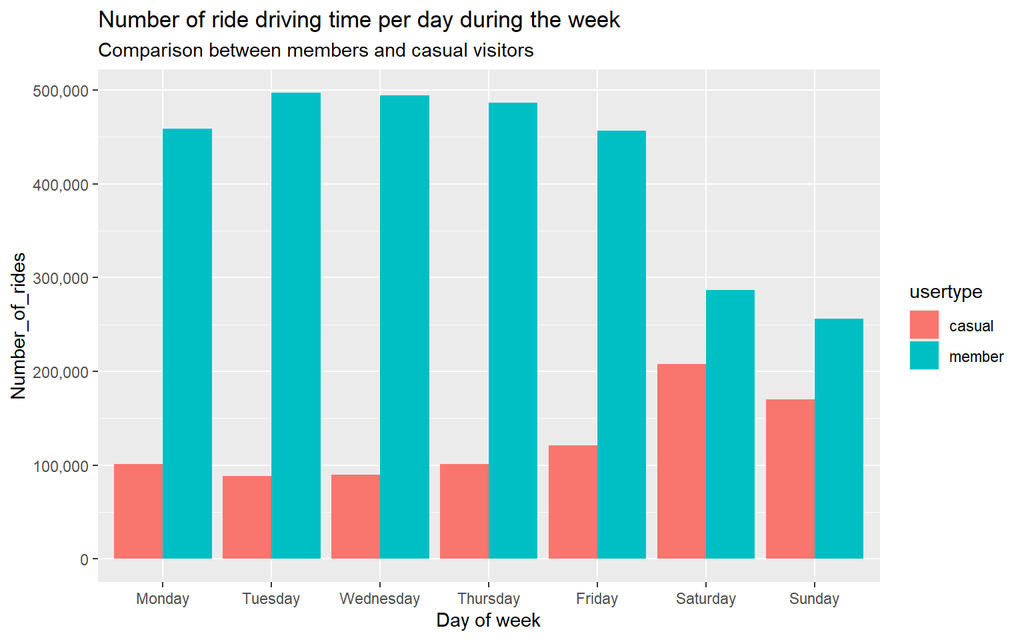

```r
All_Trip_2019_v2 %>%
  group_by(usertype,day_of_week) %>%
  summarise(number_of_rides = n(),
            Average_duration = mean(ride_length)) %>%
  arrange(usertype, day_of_week) %>%
  ggplot(mapping = aes(x = day_of_week, y = number_of_rides, fill = usertype)) + geom_col(position = "dodge") + scale_y_continuous(label = scales::comma) + labs(title = "Number of ride driving time per day during the week", subtitle = "Comparison between members and casual visitors", x = "Day of week", y = "Number_of_rides" )
```

- Observation: Who average duration ?

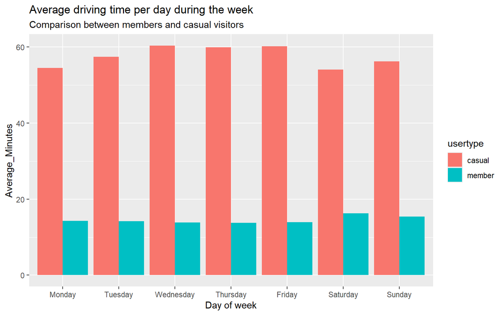

```r
All_Trip_2019_v2 %>%
  group_by(usertype, day_of_week) %>%
  summarise(number_of_rides = n(),
            Average_duration = mean(ride_length)) %>%
  arrange(usertype, day_of_week) %>%
  ggplot(mapping = aes(x = day_of_week, y = Average_duration, fill = usertype)) + geom_col(position = "dodge") + labs(title = "Average driving time per day during the week", subtitle = "Comparison between members and casual visitors", x = "Day of week", y = "Average_Minutes" )
```

# **6. Share Phase**

## Key Finding

**1. Finding 1** : The difference in usage timing between the two user types of riders during the week.

**2. Finding 2** : The difference in vehicle usage time between the two user types of riders during the week.

## Recommendations

**Strategy A: Flexible Membership Package (Leisure Focus)**

**Strategy B: Time-Based Ride Discounts**

**Strategy C: Contextual Marketing Campaign**

- **Proposal:** Run digital ads and notices at bike stations focusing on entertainment benefits on Fridays, Saturdays, and Sundays.
- **Example Ads:** “Weekend leisurely cycling? Buy a membership card to enjoy more freedom and save 50%.”
- **Rationale:** Hitting the right timing (weekend) and behavior (long visits) that data has shown to be the most common among the target customer group.